# NYPD_Shooting

Angel Ajcabul

2024-03-05

## About the data

The dataset contains a list of every shooting incident that occurred in New York City (NYC) dating back to 2006 up to the end of the previous calendar year. This data is manually extracted every quarter and reviewed by the Office of Management Analysis and Planning before being posted on the NYPD website. Each record in the dataset represents a shooting incident in NYC and includes information about the event, such as the location and time of occurrence. Additionally, demographic information related to suspects and victims is also included. The dataset is intended for public use to explore the nature of shooting and criminal activity in NYC. For additional information about the dataset, please refer to the attached data footnotes

### Import libraries

```r
library(tidyverse)
library(lubridate)
```

### Import data

```r
data <- read_csv("NYPD_Shooting_Incident_Data__Historic_ (2).csv")
head(data)
```

```
## # A tibble: 6 × 21
##   INCIDENT_KEY OCCUR_DATE OCCUR_TIME BORO     LOC_OF_OCCUR_DESC PRECINCT
##          <dbl> <chr>      <time>     <chr>    <chr>                <dbl>
## 1    228798151 05/27/2021 21:30      QUEENS   <NA>                   105
## 2    137471050 06/27/2014 17:40      BRONX    <NA>                    40
## 3    147998800 11/21/2015 03:56      QUEENS   <NA>                   108
## 4    146837977 10/09/2015 18:30      BRONX    <NA>                    44
## 5     58921844 02/19/2009 22:58      BRONX    <NA>                    47
## 6    219559682 10/21/2020 21:36      BROOKLYN <NA>                    81
## # ℹ 15 more variables: JURISDICTION_CODE <dbl>, LOC_CLASSFCTN_DESC <chr>,
## #   LOCATION_DESC <chr>, STATISTICAL_MURDER_FLAG <lgl>, PERP_AGE_GROUP <chr>,
## #   PERP_SEX <chr>, PERP_RACE <chr>, VIC_AGE_GROUP <chr>, VIC_SEX <chr>,
## #   VIC_RACE <chr>, X_COORD_CD <dbl>, Y_COORD_CD <dbl>, Latitude <dbl>,
## #   Longitude <dbl>, Lon_Lat <chr>
```

### Cleaning data

Now, we are going to use specific data

```r
data_s <- data %>% select(c(INCIDENT_KEY, OCCUR_DATE, BORO, STATISTICAL_MURDER_FLAG, VIC_AGE_GROUP, VIC_SEX))
data_s$OCCUR_DATE <- as.Date(data_s$OCCUR_DATE, format = "%m/%d/%Y")
summary(data_s)
```

```
##   INCIDENT_KEY         OCCUR_DATE             BORO
##  Min.   :  9953245   Min.   :2006-01-01   Length:27312
##  1st Qu.: 63860880   1st Qu.:2009-07-18   Class :character
##  Median : 90372218   Median :2013-04-29   Mode  :character
##  Mean   :120860536   Mean   :2014-01-06
##  3rd Qu.:188810230   3rd Qu.:2018-10-15
##  Max.   :261190187   Max.   :2022-12-31
##  STATISTICAL_MURDER_FLAG VIC_AGE_GROUP        VIC_SEX
##  Mode :logical           Length:27312       Length:27312
##  FALSE:22046             Class :character   Class :character
##  TRUE :5266              Mode  :character   Mode  :character
##
##
##
```

### Events by region

```r
data_s <- data_s %>%
  group_by(OCCUR_DATE, BORO, STATISTICAL_MURDER_FLAG, VIC_AGE_GROUP, VIC_SEX) %>%
  summarise(count = n_distinct(as.character(INCIDENT_KEY)))
```

### Visual analysis

In general, a higher number of events is observed in the age group of 25 to 44 years old, with Brooklyn and Bronx being the places with the highest frequency. It can be noted that there are values that do not have a correct age label, so they were removed from the analyzed dataset.

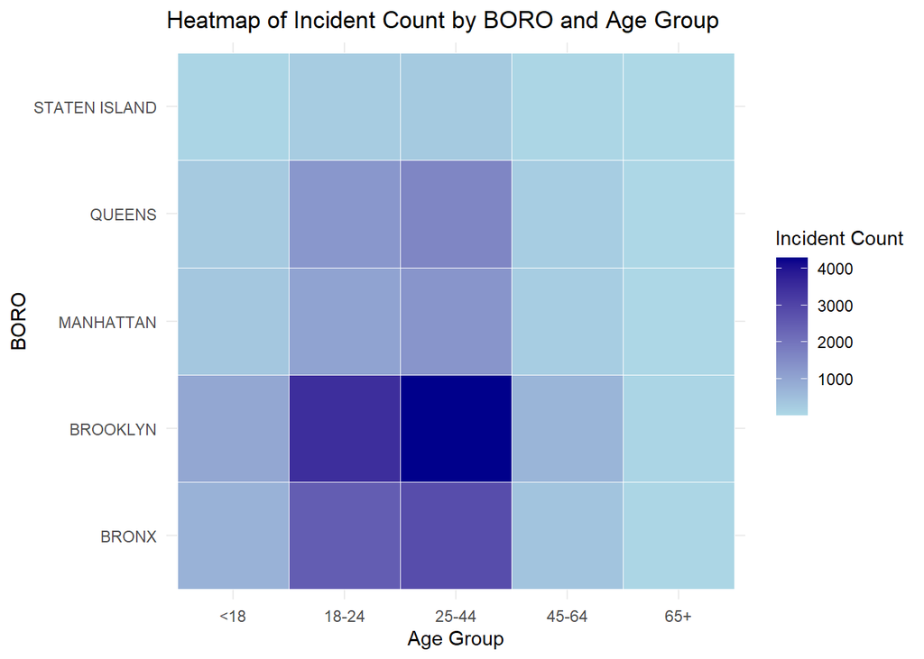

```r
heatmap_data <- data %>%
  filter(VIC_AGE_GROUP != 'UNKNOWN' & VIC_AGE_GROUP != '1022') %>%
  group_by(BORO, VIC_AGE_GROUP) %>%
  summarise(incident_count = n_distinct(INCIDENT_KEY))


ggplot(heatmap_data, aes(x = VIC_AGE_GROUP, y = BORO, fill = incident_count)) +
  geom_tile(color = "white") +
  scale_fill_gradient(low = "lightblue", high = "darkblue", name = "Incident Count") +
  labs(x = "Age Group", y = "BORO", title = "Heatmap of Incident Count by BORO and Age Group") +
  theme_minimal()
```

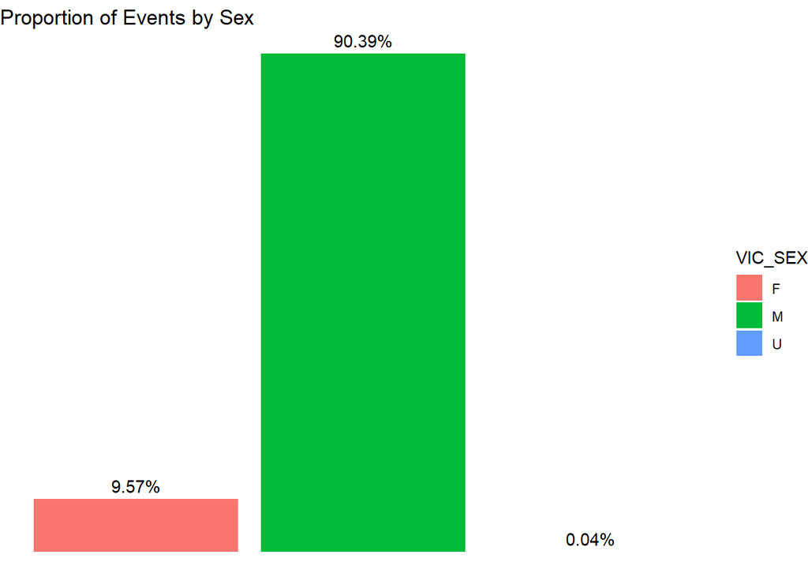

## Relationship No Murder Events vs Murder events

And finally, we want to see the relationship between the number of events involving murder and those that do not

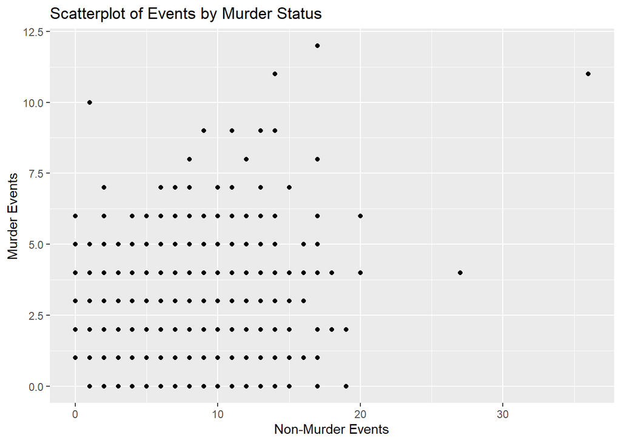

### Separate by BORO

Let’s add some color to the graph, separate it by BORO to have a better perspective.

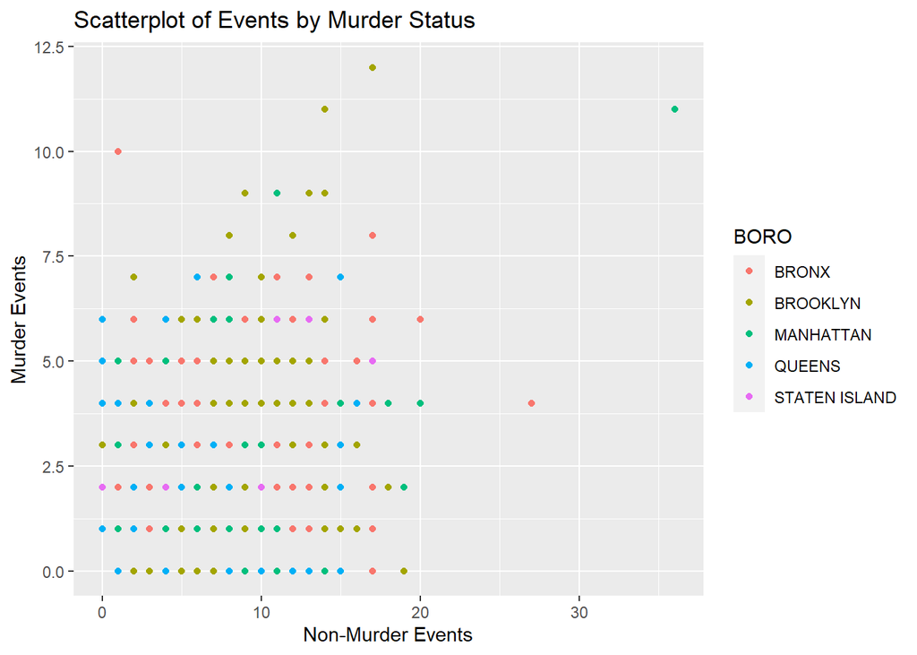

[output not shown]

[output cut: 333 more lines]

[output not shown]

### Focus on one BORO

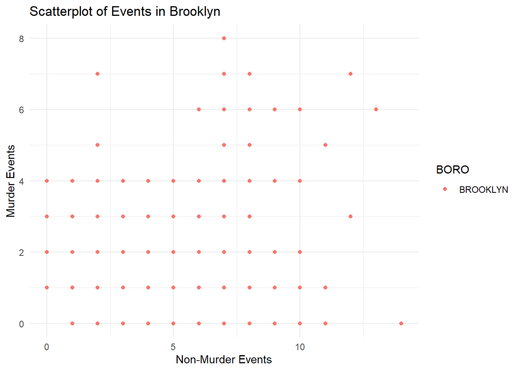

```r
brooklyn_25_44 <- data %>%
  filter(BORO == "BROOKLYN")

non_murder_events <- brooklyn_25_44 %>%
  filter(STATISTICAL_MURDER_FLAG == FALSE) %>%
  group_by(OCCUR_DATE) %>%
  summarise(non_murder_count = n())

murder_events <- brooklyn_25_44 %>%
  filter(STATISTICAL_MURDER_FLAG == TRUE) %>%
  group_by(OCCUR_DATE) %>%
  summarise(murder_count = n())

combined_data <- full_join(non_murder_events, murder_events, by = "OCCUR_DATE")


combined_data[is.na(combined_data)] <- 0

combined_data <- merge(combined_data, brooklyn_25_44[, c("OCCUR_DATE", "BORO")], by = "OCCUR_DATE", all.x = TRUE)


ggplot(combined_data, aes(x = non_murder_count, y = murder_count, color = BORO)) +
  geom_point() +
  labs(x = "Non-Murder Events", y = "Murder Events", title = "Scatterplot of Events in Brooklyn") +
  theme_minimal()
```

### Relationship between total number of events vs murders

Now let’s be more specific. Let’s examine the relationship between the total number of events and the number of murders. This will allow us to identify a pattern in the data, after which we can make a prediction with a linear model.

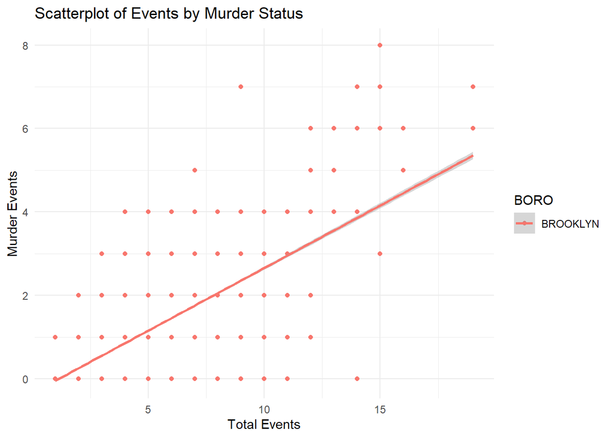

```r
brooklyn <- data %>%
  filter(BORO == "BROOKLYN")


total_events <- brooklyn %>%
  group_by(OCCUR_DATE) %>%
  summarise(total_count = n())


murder_events <- brooklyn %>%
  filter(STATISTICAL_MURDER_FLAG == TRUE) %>%
  group_by(OCCUR_DATE) %>%
  summarise(murder_count = n())

combined_data <- full_join(total_events, murder_events, by = "OCCUR_DATE")

combined_data[is.na(combined_data)] <- 0

combined_data <- merge(combined_data, brooklyn_25_44[, c("OCCUR_DATE", "BORO")], by = "OCCUR_DATE", all.x = TRUE)


ggplot(combined_data, aes(x = total_count, y = murder_count, color = BORO)) +
  geom_point() +
  labs(x = "Total Events", y = "Murder Events", title = "Scatterplot of Events by Murder Status") +
  theme_minimal()+geom_smooth(method = lm)
```

### Linear model

Now, we can plot the linear model.

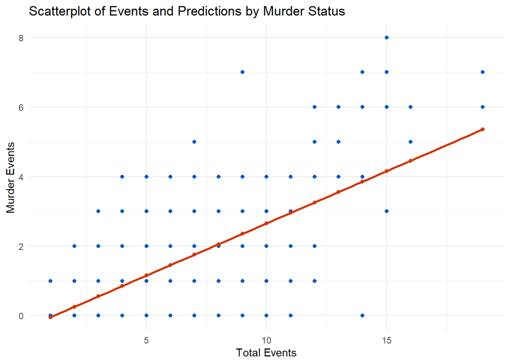

```r
combined_data[is.na(combined_data)] <- 0

model <- lm(murder_count ~ total_count, data = combined_data)

combined_data_pred <- combined_data %>%  mutate(pred = predict(model))


ggplot(combined_data_pred) +
  geom_point(aes(x = total_count, y = murder_count), color = "#0057c9") +
  geom_point(aes(x = total_count, y = pred), color = "#cf3700") +
  geom_smooth(method = "lm", se = FALSE, aes(y = pred, x= total_count), color = "#cf3700") +  # Agregar la línea de regresión
  labs(x = "Total Events", y = "Murder Events", title = "Scatterplot of Events and Predictions by Murder Status") +
  theme_minimal()
```

## Finally, this is the final model and its parameters

And de summary of the model is

```r
summary(model)
```

```
##
## Call:
## lm(formula = murder_count ~ total_count, data = combined_data)
##
## Residuals:
##     Min      1Q  Median      3Q     Max
## -3.8555 -0.5552  0.0449  0.5444  4.6446
##
## Coefficients:
##              Estimate Std. Error t value Pr(>|t|)
## (Intercept) -0.344916   0.015101  -22.84   <2e-16 ***
## total_count  0.300033   0.002967  101.13   <2e-16 ***
## ---
## Signif. codes:  0 '***' 0.001 '**' 0.01 '*' 0.05 '.' 0.1 ' ' 1
##
## Residual standard error: 0.9334 on 10931 degrees of freedom
## Multiple R-squared:  0.4834, Adjusted R-squared:  0.4833
## F-statistic: 1.023e+04 on 1 and 10931 DF,  p-value: < 2.2e-16
```